# Factor analysis

```r
library(tidyverse)
library(psych)
load("../data/tech_data.Rdata")
```

> **Goal:** Factor analysis to group diet into ‘dietary patterns’ following the guidance in [this doc](https://docs.google.com/document/d/1BEE9nCQsFzxf1p8FEV7cxyNlCC5IXvN27Y6-tOlX314/edit?usp=sharing).

## First try with `tech_nutr` data

```r
which(colnames(tech_nutr)=="GRAINS1N")
```

```
[1] 120
```

```r
which(colnames(tech_nutr)=="FRESUG1N")
```

```
[1] 154
```

```r
ids_with_2_days_recorded = tech_food |> select(ABSPID, DAYNUM) |>
   group_by(ABSPID) |>
   filter(n_distinct(DAYNUM) == 2) |>
   distinct(ABSPID)

nutr_with_age_BOTHDAYS = tech_nutr |>
  group_by(ABSPID) |>
  right_join(ids_with_2_days_recorded, by="ABSPID") |>
  left_join(y = tech_biom |> select(ABSPID, AGEC), by = "ABSPID")

nutr_with_age_BOTHDAYS_over_45 = nutr_with_age_BOTHDAYS |>
  filter(AGEC >= 45) |>
  ungroup() |>
  select(which(colnames(tech_nutr)=="GRAINS1N") : which(colnames(tech_nutr)=="FRESUG1N")) |>
  scale()


fa_result <- principal(nutr_with_age_BOTHDAYS_over_45, nfactors = 3, rotate = "varimax")
# fa.parallel(nutr_over_45_std, fa = "pc", n.iter = 100, show.legend = FALSE)
principal(nutr_with_age_BOTHDAYS_over_45, nfactors = 3, rotate = "varimax")$loadings
```

```
Loadings:
         RC2    RC1    RC3
GRAINS1N  0.224         0.539
WHOLGR1N  0.213         0.384
REFGRA1N                0.326
VEGLEG1N  0.523  0.102  0.364
GREENS1N  0.302         0.160
VGORSV1N  0.255         0.152
STARCH1N  0.162  0.116
LEGVEG1N  0.386 -0.104  0.213
OTHVEG1N  0.340         0.339
FRUIT1N   0.287 -0.114  0.463
FRSHF1N   0.222         0.325
DRFR1N    0.131         0.309
FRJUIC1N  0.152         0.222
DAIRY1N                 0.475
DAIRHF1N                0.377
DAIRMF1N                0.265
DAIRLF1N                0.170
MEAT1N    0.779  0.402 -0.222
MEATL1N   0.775  0.485 -0.263
MEATLD1N        -0.150
RDMTL1N   0.150  0.973
RDMTLU1N  0.151  0.972
RDMTLP1N                0.113
RDMTN1N   0.150  0.973
RDMTNU1N        -0.137
RDMTNP1N                0.149
PLTYL1N   0.532 -0.320 -0.520
PLTYLU1N  0.532 -0.320 -0.520
FISH1N    0.125
EGGS1N
LEGMT1N   0.389 -0.106  0.215
NUTS1N    0.511
WATER1N   0.151
UNSAT1N   0.615
FRESUG1N                0.181

                 RC2   RC1   RC3
SS loadings    3.680 3.601 2.619
Proportion Var 0.105 0.103 0.075
Cumulative Var 0.105 0.208 0.283
```

```r
fa(nutr_with_age_BOTHDAYS_over_45, nfactors = 2, rotate = "varimax")$loadings
```

```
In smc, smcs < 0 were set to .0
In smc, smcs < 0 were set to .0
In smc, smcs < 0 were set to .0
```

```
In factor.scores, the correlation matrix is singular, the pseudo inverse is  used
```

```
Loadings:
         MR1    MR2
GRAINS1N  0.220 -0.142
WHOLGR1N  0.188 -0.129
REFGRA1N  0.105
VEGLEG1N  0.488
GREENS1N  0.265
VGORSV1N  0.233
STARCH1N  0.157
LEGVEG1N  0.310 -0.189
OTHVEG1N  0.315
FRUIT1N   0.243 -0.179
FRSHF1N   0.182 -0.135
DRFR1N    0.111 -0.110
FRJUIC1N  0.130
DAIRY1N
DAIRHF1N
DAIRMF1N
DAIRLF1N
MEAT1N    0.835  0.181
MEATL1N   0.862  0.265
MEATLD1N        -0.132
RDMTL1N   0.406  0.912
RDMTLU1N  0.405  0.912
RDMTLP1N
RDMTN1N   0.406  0.912
RDMTNU1N        -0.115
RDMTNP1N
PLTYL1N   0.299 -0.264
PLTYLU1N  0.299 -0.264
FISH1N
EGGS1N
LEGMT1N   0.312 -0.193
NUTS1N    0.434 -0.156
WATER1N   0.120
UNSAT1N   0.552 -0.155
FRESUG1N

                 MR1   MR2
SS loadings    3.531 3.042
Proportion Var 0.101 0.087
Cumulative Var 0.101 0.188
```

```r
print(fa_result$loadings)
```

```
Loadings:
         RC2    RC1    RC3
GRAINS1N  0.224         0.539
WHOLGR1N  0.213         0.384
REFGRA1N                0.326
VEGLEG1N  0.523  0.102  0.364
GREENS1N  0.302         0.160
VGORSV1N  0.255         0.152
STARCH1N  0.162  0.116
LEGVEG1N  0.386 -0.104  0.213
OTHVEG1N  0.340         0.339
FRUIT1N   0.287 -0.114  0.463
FRSHF1N   0.222         0.325
DRFR1N    0.131         0.309
FRJUIC1N  0.152         0.222
DAIRY1N                 0.475
DAIRHF1N                0.377
DAIRMF1N                0.265
DAIRLF1N                0.170
MEAT1N    0.779  0.402 -0.222
MEATL1N   0.775  0.485 -0.263
MEATLD1N        -0.150
RDMTL1N   0.150  0.973
RDMTLU1N  0.151  0.972
RDMTLP1N                0.113
RDMTN1N   0.150  0.973
RDMTNU1N        -0.137
RDMTNP1N                0.149
PLTYL1N   0.532 -0.320 -0.520
PLTYLU1N  0.532 -0.320 -0.520
FISH1N    0.125
EGGS1N
LEGMT1N   0.389 -0.106  0.215
NUTS1N    0.511
WATER1N   0.151
UNSAT1N   0.615
FRESUG1N                0.181

                 RC2   RC1   RC3
SS loadings    3.680 3.601 2.619
Proportion Var 0.105 0.103 0.075
Cumulative Var 0.105 0.208 0.283
```

```r
red_meat_restructure = nutr_with_age |>
  filter(AGEC >= 45) |>
  ungroup() |>
  select(which(colnames(tech_nutr)=="GRAINS1N") : which(colnames(tech_nutr)=="FRESUG1N")) |>
  mutate(REDMT_UNPROCESSED = RDMTL1N + RDMTLU1N + RDMTN1N + RDMTNU1N) |>
  mutate(REDMT_PROCESSED = RDMTNP1N + RDMTLP1N) |>
  select(-RDMTL1N, -RDMTLU1N, -RDMTN1N, -RDMTNU1N, -RDMTNP1N, -RDMTLP1N) |>
  scale()

fa_result <- principal(red_meat_restructure, nfactors = 2, rotate = "varimax")
fa.parallel(red_meat_restructure, fa = "pc", n.iter = 100, show.legend = FALSE)

print(fa_result$loadings)
```

[output not shown]

## Retrying with `tech_food` data

Replacing 3 digit food codes with their actual meaning.

```r
library(stringr)
fooditems_dict = read.csv("../data/nutmstatDataItems2019_CSV.csv") |>
  filter(str_length(Category.Code) == 3) |>
  dplyr::rename("THRDIG" = "Category.Code")

both_days_adults_food <- tech_food |>
  group_by(ABSPID) |>
  left_join(y = tech_biom |> select(ABSPID, AGEC), by = "ABSPID") |>
  filter(n_distinct(DAYNUM) == 2, AGEC >= 45) |>
  ungroup() |>
  left_join(fooditems_dict, by = "THRDIG") |>
  select(ABSPID, Category.Label, GRAMWGT)

head(both_days_adults_food, 10)
```

```
# A tibble: 10 × 3
   ABSPID         Category.Label                   GRAMWGT
   <chr>          <chr>                              <dbl>
 1 NPA11B10000011 Breakfast cereals, ready to eat    37.8
 2 NPA11B10000011 Dairy milk (cow, sheep and goat)  206
 3 NPA11B10000011 Nuts and nut products              17.1
 4 NPA11B10000011 Tea                               150
 5 NPA11B10000011 Dairy milk (cow, sheep and goat)   30.9
 6 NPA11B10000011 Sugar, honey and syrups             6.64
 7 NPA11B10000011 Tea                               330
 8 NPA11B10000011 Dairy milk (cow, sheep and goat)   30.9
 9 NPA11B10000011 Sugar, honey and syrups             6.64
10 NPA11B10000011 Fruit, nut and seed-bars           28
```

### Normalisation (converting grams to servings)

Looking at this df, it’s clear that directly comparing the grams consumed across different types of food doesn’t really make sense. For example, comparing grams of honey with grams of meat doesn’t make much sense, because different food items have inherently different serving sizes, caloric densities, and nutritional profiles.

If we don’t standardise the grams within each food label category, the factor analysis may be biased by the average servings for different types of food having large differences in their absolute weight in grams.

> NOTE: This is important to do before grouping variables together (in next section). Otherwise, you’re doing stuff like adding up grams of wine with grams of vodka… they mean very different things. Hence, conversion of each food item from grams to servings comes first.

#### Approach 1: Z-score normalisation

```r
both_days_adults_food_Z_normalised <- both_days_adults_food |>
  group_by(Category.Label) |> # standardising WITHIN each food group.
  mutate(Grams_Zscore = (GRAMWGT - mean(GRAMWGT))/sd(GRAMWGT))

head(both_days_adults_food_Z_normalised, 10)
```

```
# A tibble: 10 × 4
# Groups:   Category.Label [6]
   ABSPID         Category.Label                   GRAMWGT Grams_Zscore
   <chr>          <chr>                              <dbl>        <dbl>
 1 NPA11B10000011 Breakfast cereals, ready to eat    37.8        -0.345
 2 NPA11B10000011 Dairy milk (cow, sheep and goat)  206           1.32
 3 NPA11B10000011 Nuts and nut products              17.1        -0.320
 4 NPA11B10000011 Tea                               150          -0.554
 5 NPA11B10000011 Dairy milk (cow, sheep and goat)   30.9        -0.476
 6 NPA11B10000011 Sugar, honey and syrups             6.64       -0.176
 7 NPA11B10000011 Tea                               330           0.332
 8 NPA11B10000011 Dairy milk (cow, sheep and goat)   30.9        -0.476
 9 NPA11B10000011 Sugar, honey and syrups             6.64       -0.176
10 NPA11B10000011 Fruit, nut and seed-bars           28          -0.177
```

Ok, this is a step in the right direction, but makes interpretation and modelling rly difficult. E.g., if someone has eaten a below-average sized serving of cereal, we definitely don’t want to say that they’re eating “negative cereal”.

#### Approach 2: Creating a “servings” measure based on grams

Looking at the food data, we can create define “1 serving” as the median grams consumed of a particular item.

From here, we just compute servings as (using tea as an example):

$$\text{Servings(Tea)} = \frac{\text{Recorded tea weight (g)}}{\text{Median tea weight (g)}}$$

By comparing grams to “servings”, we can directly compare different types of food consumed, without having to worry about how different foods are usually consumed in different weights.

```r
both_days_adults_food_servings <- both_days_adults_food |>
  group_by(Category.Label) |>
  mutate(median_grams = median(GRAMWGT)) |>
  mutate(Servings = ifelse(median_grams != 0, GRAMWGT / median_grams, 0)) # sets to 0 if median grams is 0... avoids any divide by 0 errors.

both_days_adults_food_servings$Servings <- format(both_days_adults_food_servings$Servings, scientific = FALSE)
head(both_days_adults_food_servings, 10)
```

```
# A tibble: 10 × 5
# Groups:   Category.Label [6]
   ABSPID         Category.Label                   GRAMWGT median_grams Servings
   <chr>          <chr>                              <dbl>        <dbl> <chr>
 1 NPA11B10000011 Breakfast cereals, ready to eat    37.8          38.5 "   0.9…
 2 NPA11B10000011 Dairy milk (cow, sheep and goat)  206            31.2 "   6.6…
 3 NPA11B10000011 Nuts and nut products              17.1          20   "   0.8…
 4 NPA11B10000011 Tea                               150           220   "   0.6…
 5 NPA11B10000011 Dairy milk (cow, sheep and goat)   30.9          31.2 "   0.9…
 6 NPA11B10000011 Sugar, honey and syrups             6.64          6.3 "   1.0…
 7 NPA11B10000011 Tea                               330           220   "   1.5…
 8 NPA11B10000011 Dairy milk (cow, sheep and goat)   30.9          31.2 "   0.9…
 9 NPA11B10000011 Sugar, honey and syrups             6.64          6.3 "   1.0…
10 NPA11B10000011 Fruit, nut and seed-bars           28            20   "   1.4…
```

Done :).

### Grouping categories together

#### Current state of food labels

```r
length(unique(both_days_adults_food$Category.Label))
```

```
[1] 114
```

There’s 114 different categories identified in the food diary… some of these definitely overlap.

```r
knitr::kable(table(both_days_adults_food$Category.Label))
```

| Var1 | Freq |
| --- | --- |
| Batter-based products | 271 |
| Beef, sheep and pork, unprocessed | 1869 |
| Beers | 1013 |
| Berry fruit | 481 |
| Breakfast cereals, hot porridge style | 753 |
| Breakfast cereals, ready to eat | 3141 |
| Butters | 1633 |
| Cabbage, cauliflower and similar brassica vegetables | 1090 |
| Cakes, muffins, scones, cake-type desserts | 1449 |
| Canned condensed soup (unprepared) | 10 |
| Carrot and similar root vegetables | 1727 |
| Cheese | 2535 |
| Cheese substitute | 3 |
| Chemical raising agents and cooking ingredients | 3 |
| Chocolate and chocolate-based confectionery | 1071 |
| Cider and perry | 28 |
| Citrus fruit | 1160 |
| Coffee and coffee substitutes | 8251 |
| Cordials | 386 |
| Corn snacks | 72 |
| Cream | 351 |
| Crustacea and molluscs (excluding commercially sterile) | 112 |
| Custards | 167 |
| Dairy blends | 328 |
| Dairy milk (cow, sheep and goat) | 12897 |
| Dairy milk substitutes, unflavoured | 472 |
| Dips | 236 |
| Dishes and products other than confectionery where sugar is the major component | 200 |
| Dishes where egg is the major ingredient | 377 |
| Dishes where meat substitutes are the major component | 5 |

[output cut: 84 more lines]

#### One row per individual

> Preparing for grouping.

```r
wide_adults_food_servings = both_days_adults_food_servings |>
  select(-GRAMWGT, -median_grams) |>
  mutate(Servings = as.numeric(Servings)) |>
  group_by(ABSPID, Category.Label) |>
  summarise(Total_Servings = sum(Servings, na.rm = TRUE), .groups = 'drop') |>
  pivot_wider(names_from = Category.Label, values_from = Total_Servings, values_fill = 0)

head(wide_adults_food_servings, 10)
```

```
# A tibble: 10 × 115
   ABSPID     `Berry fruit` Breakfast cereals, r…¹ Cheese Chocolate and chocol…²
   <chr>              <dbl>                  <dbl>  <dbl>                  <dbl>
 1 NPA11B100…        0.0273                  2.4    2.21                    1
 2 NPA11B100…        0                       0      1.12                    0
 3 NPA11B100…        0                       2.38   0.576                   0.64
 4 NPA11B100…        0.273                   2.34   3.75                    1.4
 5 NPA11B100…        0                       0      1                       0.68
 6 NPA11B100…        0                       1.77   4                       2.68
 7 NPA11B100…        2.25                    0      4.50                    0
 8 NPA11B100…        0                       0.909  0.384                   0
 9 NPA11B100…        0                       0      0.28                    0
10 NPA11B100…        6.25                    0      0                       0
# ℹ abbreviated names: ¹`Breakfast cereals, ready to eat`,
#   ²`Chocolate and chocolate-based confectionery`
# ℹ 110 more variables: `Coffee and coffee substitutes` <dbl>, Cordials <dbl>,
#   `Dairy milk (cow, sheep and goat)` <dbl>,
#   `Dishes where vegetable is the major component` <dbl>,
#   `Dried fruit, preserved fruit` <dbl>,
#   `Fin fish (excluding commercially sterile)` <dbl>, …
```

#### Grouping food items together with substantial overlap.

Merging together overlapping food items (columns) aids w factor analysis.

**Note:** Relatively niche ingredients with minimal nutritional content (e.g. baking soda, herbs) will be removed.

```r
wide_adults_food_servings_foods_grouped <- wide_adults_food_servings |>
  # Removing variables with minimal nutritional content and/or rare groups, which don't fit in with anything else.
  select(-c(
    `Herbs, spices, seasonings and stock cubes`, # this also includes added salt..? Should be careful.
    `Essences`,
    `Stuffings`,
    `Chemical raising agents and cooking ingredients`,
    `Infant foods`,
    `Infant cereal products`,
    `Formula dietary foods` # kind of raises an eyebrow that there's consumption of infant products for 45+ aged people... Double check data.
    )) |>
  # Soups
  mutate(Soups = rowSums(across(matches("Soup", ignore.case = TRUE)), na.rm = TRUE)) |>
  select(-matches("Soup"), Soups) |>
  # Fish
  mutate(`Fish and Fish Products` = rowSums(across(c(
    `Other sea and freshwater foods`,
    `Crustacea and molluscs (excluding commercially sterile)`,
    `Fish and seafood products (homemade and takeaway)`,
    `Mixed dishes with fish or seafood as the major component`,
    `Packed (commercially sterile) fish and seafood`,
    `Fin fish (excluding commercially sterile)`
    )), na.rm = TRUE)) |>
  select(-c(
    `Other sea and freshwater foods`,
    `Crustacea and molluscs (excluding commercially sterile)`,
    `Fish and seafood products (homemade and takeaway)`,
    `Mixed dishes with fish or seafood as the major component`,
    `Packed (commercially sterile) fish and seafood`,
    `Fin fish (excluding commercially sterile)`)) |>
  # Fruit
  mutate(`Fresh Fruit and Fruit-based Dishes` = rowSums(across(c(
    `Berry fruit`,
    `Stone fruit`,
    `Citrus fruit`,
    `Other fruit`,
    `Pome fruit`,
    `Tropical and subtropical fruit`,
    `Mixtures of two or more groups of fruit`
    )))) |>
  select(-`Berry fruit`, -`Stone fruit`, -`Citrus fruit`, -`Other fruit`, -`Pome fruit`, -`Tropical and subtropical fruit`, -`Mixtures of two or more groups of fruit`) |>
  # Fruit and muesli bars
  mutate(`Fruit and Muesli-style bars` = rowSums(across(c(
    `Fruit, nut and seed-bars`,
    `Muesli or cereal style bars`)))) |>
  select(-c(`Fruit, nut and seed-bars`,
            `Muesli or cereal style bars`)) |>
  # Cordials and soft drink
  mutate(`Soft drinks, Cordials, Sports drinks, and Milkshakes` = rowSums(across(c(
    `Soft drinks, and flavoured mineral waters`,
    `Cordials`,
    `Flavoured milks and milkshakes`,
    `Electrolyte, energy and fortified drinks`)))) |>
  select(-c(`Soft drinks, and flavoured mineral waters`,
            `Cordials`,
            `Flavoured milks and milkshakes`,
            `Electrolyte, energy and fortified drinks`)) |>
  # Desserts
  mutate(`Milk-based and other dessert items` = rowSums(across(c(
    `Other dishes where milk or a milk product is the major component`,
    `Sweet biscuits`,
    `Frozen milk products`,
    `Dishes and products other than confectionery where sugar is the major component`,
    `Custards`,
    `Soy-based ice confection`,
    `Batter-based products`,
    `Mixed dishes where fruit is the major component`,
    `Cakes, muffins, scones, cake-type desserts`)))) |>
  select(-c(`Other dishes where milk or a milk product is the major component`,
            `Sweet biscuits`,
            `Frozen milk products`,
            `Dishes and products other than confectionery where sugar is the major component`,
            `Mixed dishes where fruit is the major component`,
            `Custards`, `Soy-based ice confection`, `Batter-based products`, `Cakes, muffins, scones, cake-type desserts`)) |>
  # Chocolate and lollies
  mutate(`Chocolate and lollies` = rowSums(across(c(
    `Chocolate and chocolate-based confectionery`,
    `Other confectionery`)))) |>
  select(-c(`Chocolate and chocolate-based confectionery`,
            `Other confectionery`)) |>
  # Butters, margarines, and oils
  mutate(`Butters, margarines, and oils` = rowSums(across(c(
    `Butters`,
    `Margarine and table spreads`,
    `Plant oils`,
    `Unspecified fats`,
    `Dairy blends`,
    `Other fats`)))) |>
  select(-c(`Butters`, `Margarine and table spreads`, `Plant oils`, `Unspecified fats`, `Dairy blends`, `Other fats`)) |>
  # Sauces
  mutate(`Sauces` = rowSums(across(c(`Gravies and savoury sauces`, `Salad dressings`)))) |>
  select(-c(`Gravies and savoury sauces`, `Salad dressings`)) |>
  # Coffee and Tea
  mutate(`Coffee and Tea` = rowSums(across(c(`Coffee and coffee substitutes`, `Tea`)))) |>
  select(-c(`Coffee and coffee substitutes`, `Tea`)) |>
  # Starchy snacks
  mutate(`Starchy snacks` = rowSums(across(c(
    `Extruded or reformed snacks`,
    `Other snacks`,
    `Corn snacks`,
    `Potato snacks`
    )))) |>
  select(-c(
    `Extruded or reformed snacks`,
    `Other snacks`,
    `Corn snacks`,
    `Potato snacks`)) |>
  # Alcohol
  mutate(`Alcohol` = rowSums(across(c(
    `Wines`,
    `Beers`,
    `Spirits`,
    `Cider and perry`,
    `Other alcoholic beverages`
  )))) |>
  select(-c(
    `Wines`,
    `Beers`,
    `Spirits`,
    `Cider and perry`,
    `Other alcoholic beverages`
  )) |>
  # Legumes
  mutate(`Legumes and pulses` = rowSums(across(c(
    `Peas and beans`,
    `Mature legumes and pulses`,
    `Mature legume and pulse products and dishes`
  )))) |>
  select(-c(
    `Peas and beans`,
    `Mature legumes and pulses`,
    `Mature legume and pulse products and dishes`
  )) |>
  # Breakfast cereal and porridge
  mutate(`Breakfast cereal and porridge` = rowSums(across(c(
    `Breakfast cereals, ready to eat`,
    `Breakfast cereals, hot porridge style`
  )))) |>
  select(-c(
    `Breakfast cereals, ready to eat`,
    `Breakfast cereals, hot porridge style`)) |>
  # Cheese, yogurts
  mutate(`Cheese, yogurt, cream` = rowSums(across(c(
    `Cheese`,
    `Yoghurt`,
    `Cream`
  )))) |>
  select(-c(
    `Cheese`,
    `Yoghurt`,
    `Cream`
  )) |>
  # Processed meat
  mutate(`Processed meats` = rowSums(across(c(
    `Processed meat`,
    `Sausages, frankfurts and saveloys`
  )))) |>
  select(-c(
    `Processed meat`,
    `Sausages, frankfurts and saveloys`
  )) |>
  # Red meat, unprocessed
  mutate(`Red meat, unprocessed` = rowSums(across(c(
    `Beef, sheep and pork, unprocessed`,
    `Mammalian game meats`,
  )))) |>
  select(-c(
    `Beef, sheep and pork, unprocessed`,
    `Mammalian game meats`,
  )) |>
  # Eggs and egg dishes
  mutate(`Eggs and egg dishes` = rowSums(across(c(
    `Eggs`,
    `Dishes where egg is the major ingredient`,
  )))) |>
  select(-c(
    `Eggs`,
    `Dishes where egg is the major ingredient`,
  ))

# This is actually quite annoying... `mixed dishes where cereal is main component` includes sandwiches, sushi, pizza, etc...

## Testing
```

> Results of variable merging (so far).

```r
colnames(wide_adults_food_servings_foods_grouped)
```

```
 [1] "ABSPID"
 [2] "Dairy milk (cow, sheep and goat)"
 [3] "Dishes where vegetable is the major component"
 [4] "Dried fruit, preserved fruit"
 [5] "Flours and other cereal grains and starches"
 [6] "Fruit and vegetable juices, and drinks"
 [7] "Leaf and stalk vegetables"
 [8] "Mixed dishes where cereal is the major ingredient"
 [9] "Mixed dishes where poultry or feathered game is the major component"
[10] "Nuts and nut products"
[11] "Pickles, chutneys and relishes"
[12] "Potatoes"
[13] "Regular breads, and bread rolls (plain/unfilled/untopped varieties)"
[14] "Sugar, honey and syrups"
[15] "Waters, municipal and bottled, unflavoured"
```

[output cut: 42 more lines]

```r
#wide_adults_food_grams |> select(matches("fish", ignore.case = TRUE))
```

### Running factor analysis on grouped data

```r
fa_grouped_result = fa(wide_adults_food_servings_foods_grouped |> select(-ABSPID) |> scale(), fm = "pa", nfactors = 2, rotate = "varimax")
fa_grouped_loadings = fa_grouped_result$loadings

data.frame(group_1 = fa_grouped_result$loadings[,1], group_2 = fa_grouped_result$loadings[,2]) |>
  mutate(group_1 = ifelse(abs(group_1) >= 0.15, group_1, " ")) |>
  mutate(group_2 = ifelse(abs(group_2) >= 0.15, group_2, " ")) |>
  knitr::kable() |> kableExtra::kable_material()
```

|  | group_1 | group_2 |
| --- | --- | --- |
| Dairy milk (cow, sheep and goat) | 0.218891263037505 |  |
| Dishes where vegetable is the major component | -0.179707098303832 |  |
| Dried fruit, preserved fruit |  |  |
| Flours and other cereal grains and starches | -0.234398150966942 |  |
| Fruit and vegetable juices, and drinks |  |  |
| Leaf and stalk vegetables |  |  |
| Mixed dishes where cereal is the major ingredient |  | -0.234235181417432 |
| Mixed dishes where poultry or feathered game is the major component |  |  |
| Nuts and nut products |  |  |
| Pickles, chutneys and relishes |  |  |
| Potatoes | 0.273227330571387 | 0.344083662144658 |
| Regular breads, and bread rolls (plain/unfilled/untopped varieties) | 0.431785994683761 |  |
| Sugar, honey and syrups | 0.323843348844726 |  |
| Waters, municipal and bottled, unflavoured | -0.282042435141162 |  |
| Poultry and feathered game |  |  |
| Cabbage, cauliflower and similar brassica vegetables |  | 0.316603997753508 |
| Carrot and similar root vegetables |  | 0.459421401876649 |
| Pastries |  |  |
| Savoury biscuits |  |  |
| Other fruiting vegetables |  | 0.440797499764757 |
| Other vegetables and vegetable combinations |  |  |
| Jam and lemon spreads, chocolate spreads, sauces |  |  |
| Tomato and tomato products |  | 0.187278458075674 |
| Yeast, and yeast vegetable or meat extracts | 0.158839500970471 |  |
| Mixed dishes where beef, sheep, pork or mammalian game is the major component |  |  |
| Pasta and pasta products (without sauce) |  |  |
| Dips |  |  |
| English-style muffins, flat breads, and savoury and sweet breads |  |  |
| Dairy milk substitutes, unflavoured | -0.162184841674868 |  |
| Other beverage flavourings and prepared beverages |  |  |
| Intense sweetening agents |  |  |
| Organ meats and offal, products and dishes |  |  |
| Seeds and seed products |  |  |
| Cheese substitute |  |  |
| Meat substitutes |  |  |
| Dishes where meat substitutes are the major component |  |  |
| Mixed dishes where sausage, bacon, ham or other processed meat is the major component |  |  |
| Soy-based yoghurts |  |  |
| Soups |  |  |
| Fish and Fish Products |  |  |
| Fresh Fruit and Fruit-based Dishes | -0.194710945828648 | 0.186450279773247 |
| Fruit and Muesli-style bars |  |  |
| Soft drinks, Cordials, Sports drinks, and Milkshakes |  |  |
| Milk-based and other dessert items | 0.266599916626454 |  |
| Chocolate and lollies |  |  |
| Butters, margarines, and oils | 0.521053015462073 |  |
| Sauces |  |  |
| Coffee and Tea | 0.196119462129576 |  |
| Starchy snacks |  |  |
| Alcohol |  |  |
| Legumes and pulses |  | 0.323047310485026 |
| Breakfast cereal and porridge |  |  |
| Cheese, yogurt, cream |  |  |
| Processed meats | 0.263467504245244 |  |
| Red meat, unprocessed |  | 0.299601716618827 |
| Eggs and egg dishes |  |  |

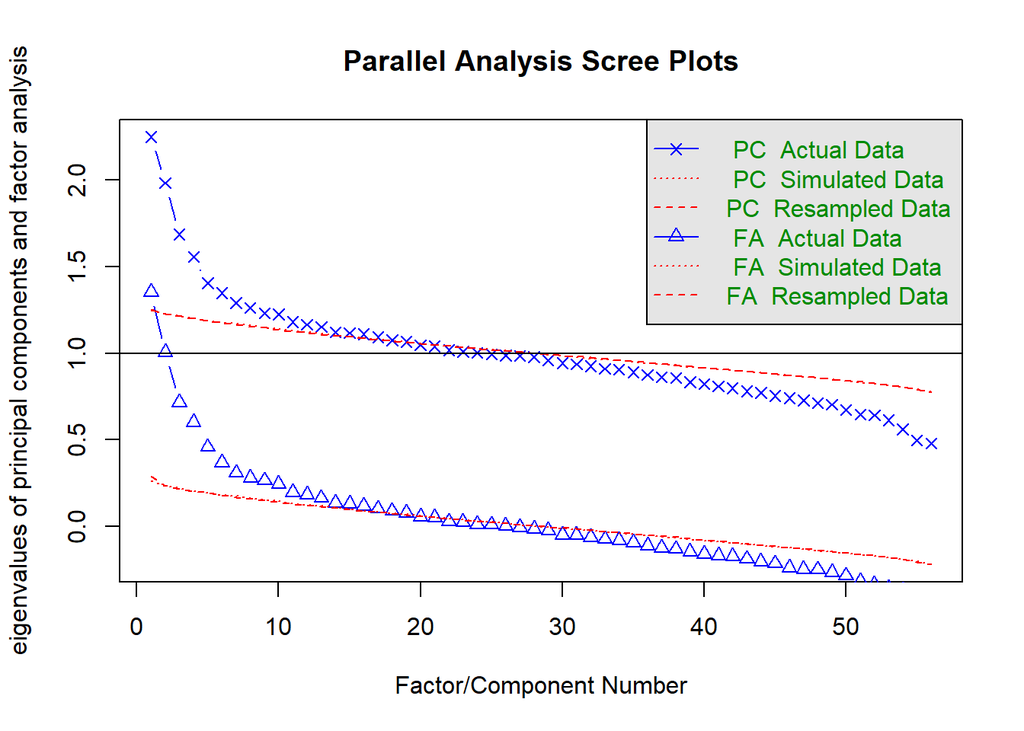

```
Parallel analysis suggests that the number of factors =  19  and the number of components =  17
```

```r
# scree plot
fa.parallel(wide_adults_food_servings_foods_grouped |> select(-ABSPID) |> scale(), fm = "pa")
```

```r
# Now, use factor analysis scores for regression.
fa_scores = fa_grouped_result$scores
fa_scores_w_ids = data.frame(ABSPID = wide_adults_food_servings_foods_grouped$ABSPID, fa_scores)

merged_with_biom_dat = merge(tech_biom, fa_scores_w_ids, by = "ABSPID")

summary(lm(PHDCMWBC ~ PA1 + PA2, data = merged_with_biom_dat))
```

```
Call:
lm(formula = PHDCMWBC ~ PA1 + PA2, data = merged_with_biom_dat)

Residuals:
    Min      1Q  Median      3Q     Max
-46.843 -10.214  -0.115   9.018  47.326

Coefficients:
            Estimate Std. Error t value Pr(>|t|)
(Intercept)  96.4141     0.2574 374.589   <2e-16 ***
PA1           3.4332     0.3275  10.484   <2e-16 ***
PA2          -0.4880     0.3375  -1.446    0.148
---
Signif. codes:  0 '***' 0.001 '**' 0.01 '*' 0.05 '.' 0.1 ' ' 1

Residual standard error: 14.2 on 3042 degrees of freedom
  (435 observations deleted due to missingness)
Multiple R-squared:  0.03523,   Adjusted R-squared:  0.0346
F-statistic: 55.54 on 2 and 3042 DF,  p-value: < 2.2e-16
```

Promising results! Unhealthy group (group 1) has generally lower consumption of veg and fruit, higher consumption of junk food, etc. This group was positively correlated with waist circumference (p<0.05).

### Next steps:

**Finding out more about factor analysis (vs PCA):** - What’s actually the difference between factor analysis using `psych::fa(fm = "pa")` (i.e. factor analysis by the principal component method) and `psych::principal()`?

**Is explaining a low proportion of the variance in factor analysis a problem?** - There’s still a lot of work to be done in grouping similar food items together, but currently, the proportion of variance explained by the 2 factors is really low (like 2% each). - The authors of the paper we were looking at [here](https://www.mdpi.com/2072-6643/7/8/5295#B17-nutrients-07-05295) had similar results, though, and didn’t think it was a problem for their use case. - Would be worth asking in class about, or doing our own research into.

**Controlling for confounders**: - Try refitting the model, but adding total energy (kJ) consumed as a predictor. - You’ll have to get this data from `tech_nutr` I believe, and join it with the dataset before modelling. - Worth adding other confounders too. Again, [this paper](https://www.mdpi.com/2072-6643/7/8/5295#B17-nutrients-07-05295) had some good examples of different confounders they fitted inside the model so they could control for their effect. - What difference does this make to $R^2$?